# Introduction to **do** function and what **do** can do for you

Matt Dzievit

### Source of data: https://www.nass.usda.gov/

Downloaded August, 15th, 2017

### Assumptions

This walkthrouh assumes a working knowledge of tidyverse functions, specifically dplyr and ggplot2

### Load necessary libraries

Tidyverse of course!

```r
requiredPackages <- c('tidyverse','broom')
for(p in requiredPackages){
  if(!require(p,character.only = TRUE)) install.packages(p)
  library(p,character.only = TRUE)
}
```

## 1. Import, inspect, and mutate US_Data

Load the datafile, uses readr format to import. Sets missing data to “” if any

```r
us_data <- read_csv("US_Yield_Data.csv", na = "")
head(us_data)
```

| Year | Yield_bu_acre |
| --- | --- |
| 2016 | 174.6 |
| 2015 | 168.4 |
| 2014 | 171.0 |
| 2013 | 158.1 |
| 2012 | 123.1 |
| 2011 | 146.8 |

Provides summary of the data columns. We have 2 yield in bu/acre and Year

Also look at a sumamry of the data to see what we are working with

```r
summary(us_data)
```

```
##       Year      Yield_bu_acre
##  Min.   :1866   Min.   : 18.20
##  1st Qu.:1904   1st Qu.: 26.50
##  Median :1941   Median : 31.20
##  Mean   :1941   Mean   : 60.68
##  3rd Qu.:1978   3rd Qu.: 91.15
##  Max.   :2016   Max.   :174.60
```

### Make some new columns that define the period based on year and convert to kg/ha

Period defines the type of advancement that was in place during that time period

```r
us_data <- us_data %>%
  mutate(Yield_kg_ha = Yield_bu_acre*62.765,
         Period = ifelse(Year <= 1936, "OPV",
                         ifelse(Year <= 1955, "Double Cross Hybrid",
                                ifelse(Year <= 1995, "Single Cross Hybrid",
                                       "Biotech"))))
head(us_data)
```

| Year | Yield_bu_acre | Yield_kg_ha | Period |
| --- | --- | --- | --- |
| 2016 | 174.6 | 10958.769 | Biotech |
| 2015 | 168.4 | 10569.626 | Biotech |
| 2014 | 171.0 | 10732.815 | Biotech |
| 2013 | 158.1 | 9923.146 | Biotech |
| 2012 | 123.1 | 7726.371 | Biotech |
| 2011 | 146.8 | 9213.902 | Biotech |

## 2. Create a model function

We are going to create a model that we are going to apply over the different periods. We are only interested in the slopes for each time period as we want to see what the yield gain was during that time.

```r
le_lin_fit <- function(data) {
  the_fit_ha <- lm(Yield_kg_ha ~ Year, data)
  the_fit_bu <- lm(Yield_bu_acre ~ Year,data)
  return(as.tibble(cbind(slope_ha = coef(the_fit_ha)[2],slope_bu = coef(the_fit_bu)[2])))
}
```

## 3. Apply regression to data

We are going to apply the function we created to each period. First we need to group_by period Then we can **“do”** to function across each group. The ‘.’ in the function represents the subsetted tibble that is being passed to the next step. So the function is only going to be applied to that specific portion of the data. 2 new variables were added (xax and yax) this has nothing to do with do, but more to do with plotting the slopes on the graph.

```r
us_data_reg <- us_data %>%
  group_by(Period) %>%
  do(le_lin_fit(.)) %>%
  mutate(xax = ifelse(Period == "OPV",1895,
                      ifelse(Period == "Double Cross Hybrid",1930,
                             ifelse(Period == "Single Cross Hybrid",1950,1985))),
         yax = ifelse(Period == "OPV",2750,
                      ifelse(Period == "Double Cross Hybrid",3250,
                             ifelse(Period == "Single Cross Hybrid",6500,10500))))
head(us_data_reg)
```

| Period | slope_ha | slope_bu | xax | yax |
| --- | --- | --- | --- | --- |
| Biotech | 115.911468 | 1.84675325 | 1985 | 10500 |
| Double Cross Hybrid | 47.976685 | 0.76438596 | 1930 | 3250 |
| OPV | -1.148376 | -0.01829645 | 1895 | 2750 |
| Single Cross Hybrid | 116.917771 | 1.86278612 | 1950 | 6500 |

We can see what the dataframe looks like. We specifically chose what we wanted to pull from the linear model and created a tibble. When you use do in the dplyr:piping format, the data needs to be in a tibble or data.frame. It won’t take a single value, it doesn’t know how to deal with that.

## 5. Alternative way to use do

Instead of pulling specific data from the model, what if we want everything? Two ways 1.

```r
us_data_reg_alt <- us_data %>%
  group_by(Period) %>%
  do(tidy(lm(Yield_bu_acre ~ Year, .)))
head(us_data_reg_alt)
```

| Period | term | estimate | std.error | statistic | p.value |
| --- | --- | --- | --- | --- | --- |
| Biotech | (Intercept) | -3.557497e+03 | 758.27545535 | -4.691562 | 1.589201e-04 |
| Biotech | Year | 1.846753e+00 | 0.37800199 | 4.885565 | 1.027034e-04 |
| Double Cross Hybrid | (Intercept) | -1.452400e+03 | 223.66534238 | -6.493632 | 5.510543e-06 |
| Double Cross Hybrid | Year | 7.643860e-01 | 0.11493549 | 6.650565 | 4.094059e-06 |
| OPV | (Intercept) | 6.060408e+01 | 33.18557832 | 1.826217 | 7.214394e-02 |
| OPV | Year | -1.829645e-02 | 0.01745589 | -1.048153 | 2.982258e-01 |

We see that we get information about the intercept and slope for each period and some test statistics associated with it.

What if you want to save all the data from the model? 2.

```r
us_data_reg_alt2 <- us_data %>%
  group_by(Period) %>%
  do(fit = (lm(Yield_bu_acre ~ Year, .)))
head(us_data_reg_alt2)
```

| Period | fit |
| --- | --- |
| Biotech |  |
| Double Cross Hybrid |  |
| OPV |  |
| Single Cross Hybrid |  |

Now we have a tibble of linear models. We can access each one by using **tidy** and other methods to access the other portions of the lm

```r
us_data_reg_alt2 %>%
  tidy(fit)
```

| Period | term | estimate | std.error | statistic | p.value |
| --- | --- | --- | --- | --- | --- |
| Biotech | (Intercept) | -3.557497e+03 | 758.27545535 | -4.691562 | 1.589201e-04 |
| Biotech | Year | 1.846753e+00 | 0.37800199 | 4.885565 | 1.027034e-04 |
| Double Cross Hybrid | (Intercept) | -1.452400e+03 | 223.66534238 | -6.493632 | 5.510543e-06 |
| Double Cross Hybrid | Year | 7.643860e-01 | 0.11493549 | 6.650565 | 4.094059e-06 |
| OPV | (Intercept) | 6.060408e+01 | 33.18557832 | 1.826217 | 7.214394e-02 |
| OPV | Year | -1.829645e-02 | 0.01745589 | -1.048153 | 2.982258e-01 |
| Single Cross Hybrid | (Intercept) | -3.590591e+03 | 279.44425490 | -12.849044 | 2.095036e-15 |
| Single Cross Hybrid | Year | 1.862786e+00 | 0.14145254 | 13.168984 | 9.725127e-16 |

## 4. Setting the priod names.

This will be used for the figure

```r
period_Name <- c("OPV\n(1866-1936)\n","Double Cross Hybrid\n(1937-1955)\n",
                 "Single Cross Hybrid\n(1956-1995)\n",
                 "Biotech\n(1996 - Current)\n")
```

## 5. Plotting the data

There is a lot of formatting in here to make the plot look “pretty” The slope tibble we create was used to plot the slopes on each period to match the lines that were plotted for each time period.

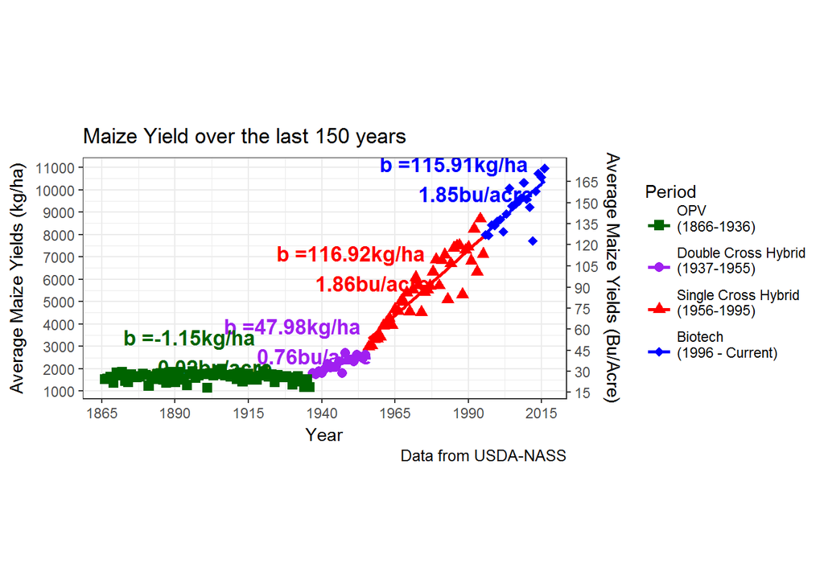

```r
us_yield <- us_data %>%
  mutate(Period = factor(Period,levels = c("OPV","Double Cross Hybrid",
                                           "Single Cross Hybrid","Biotech"))) %>%
  ggplot(aes(x = Year,y = Yield_kg_ha, group = Period)) +
  geom_point(aes(color = Period, shape = Period), size = 2.5) +
  theme_bw() +
  geom_smooth(aes(color = Period),method = 'lm', se = FALSE, size = 1) +
  scale_x_continuous(breaks = seq(from = 1865, to = 2016,by = 25)) +
  labs(title = "Maize Yield over the last 150 years",
       y = "Average Maize Yields (kg/ha)",
       caption = "Data from USDA-NASS") +
  scale_y_continuous(breaks = seq(from = 1000, to = 11000, by = 1000),
                     sec.axis = sec_axis( ~./62.765,
                                          name = "Average Maize Yields (Bu/Acre)",
                                          breaks = seq(from = 15, to = 175, by = 15))) +
  geom_text(data = us_data_reg,aes(xax, yax, color = Period,
                                   label = paste("b =" ,round(slope_ha,2),
                                                 "kg/ha\n        ",round(slope_bu,2),
                                                 "bu/acre",sep = "")),
            size = 4.5,fontface = "bold",show.legend = FALSE) +
  scale_color_manual(values = c("DarkGreen","Purple","Red","Blue"),
                     labels = period_Name) +
  scale_shape_manual(values = c(15,16,17,18),
                     labels = period_Name) +
  theme(aspect.ratio = .5)
us_yield
```